# Homework

Nikolaj Schaldemose Reibke

11/21/2014

# Table of Content

- Introduction to Data 1
  - 1.1 - Migrane and acupuncture
  - 1.6 - Smoking habits of UK residents
  - 1.12 - Internet use and Life Expectations
  - 1.21 - Exercise and Mental Health
- Introduction to Data 2
  - 1.27 - Make up Exam
  - 1.40 - Marathon Winners
  - 1.41 - Robust Statistic
  - 1.50 - Heart transplant, Part 1
  - 1.54 - Sinusitis and antibiotics, Part 2
- Probability 1
  - 2.12 - School Absences
  - 2.22 - Predisposition
- Probability 2
  - 2.28 - Socks in a Drawer
  - 2.40 - Baggage Fees
- Distributions of random variables 1
  - 3.10 - Heights of 10 year olds
  - 3.12 - Speeding on the I-5, Part 1
  - 3.20 - Heights of female college students, Part 2
  - 3.26 - Speeding on the I-5, Part 2
- Distributions of random variables 2
  - 3.28 - Chickenpox, Part 1
  - 3.40 - Male Children
- Foundations for inference 1
  - 4.4 - Heights of adults
  - 4.12 - Thanksgiving spending, Part 1
  - 4.32 - Speed reading, Part 1
- Foundations for inference 2
  - 4.38 - Stats final scores
  - 4.46 - Unemployment and relationship problems
  - 4.48 - True or false
- Inference for Numerical Data 1
  - 5.1 - Global warming, Part 1
  - 5.14 - Child care hours, Part 1
  - 5.20 - Fuel efficiency of Prius
- Inference for Numerical Data 2
  - 5.30 - Fuel efficiency of manual and automatic cars, Part 1
  - 5.40 - Work hours and education, Part 3
- Inference for Categorical Data
  - 6.12 - Legalization of marijuana, Part 1
  - 6.14 - The Civil War

# Homework

## Introduction to Data 1

**Assingments Overview**:

- 1.1 - Migrane and acupuncture
- 1.6 - Smoking habits of UK residents
- 1.12 - Internet use and Life Expectations
- 1.21 - Exercise and Mental Health

### 1.1 Migrane and Acupuncture

| Group | Yes | No | Total |
| --- | --- | --- | --- |
| Treatment | 10 | 33 | 43 |
| Control | 2 | 44 | 46 |
| Total | 12 | 77 | 89 |

1. What percent of patients in the treatment group were pain free 24 hours after receiving acupuncture? What percent is in the control group?

```r
{
treatment_pain_free <- 10 / 43
print("The percentage of patients in the treatment group which was pain free after 24 hours is: ")
print(treatment_pain_free) # Outputs: 0.2325581


control_pain_free <- 2 / 44
print("The percentage of patients in the control group which was pain free after 24 hours is: ")
print(control_pain_free) # Outputs: 0.04545455
}
```

```
## [1] "The percentage of patients in the treatment group which was pain free after 24 hours is: "
## [1] 0.2325581
## [1] "The percentage of patients in the control group which was pain free after 24 hours is: "
## [1] 0.04545455
```

2. At first glance, does acupuncture appear to be an effective treatment for migranes? Explain Your reasoning.

It does seem to be somewhat effective. But still not “a cure” since it’s still only a very small portion of people it actually works on. If it was used together with a lot of other options it might increase the overall total of people having migrane to be pain free

3. Do the data provide convincing evidence that there is a real pain reduciton for those patients in the treatment group

1 in 5 higher than those in the control group, seems somewhat convincing. There can’t be said for certain that it wasn’t just due to luck though. But there is a high chance that this for 1 in 4 was a real pain reduction.

### 1.6 - Smoking habits of UK residents

| Cigarette Habits | gender | age | marital | grossIncome | smoke | amtWeekend | amtWeekdays |
| --- | --- | --- | --- | --- | --- | --- | --- |
| 1 | Female | 42 | Single | Under £ 2600 | yes | 12 cig/day | 12 cig/day |
| 2 | Male | 44 | Single | £ 10400 - 15600 | No | N/A | N/A |
| 3 | Male | 53 | Married | Above £ 36400 | Yes | 6 cig/day | 6 cig/day |
| . | . | . | . | . | . | . | . |
| . | . | . | . | . | . | . | . |
| 1691 | Male | 40 | Single | £ 2600 - 5200 | Yes | 8 cig/day | 8 cig/day |

1. What does each row of the matrix represent?

Each row of the matric represent an observation of a persons cigarette behaviour. The information from each person is as the following:

- gender
- age
- marital
- grossIncome
- smoke
- amtWeekend
- amtWeekdays
2. How many participants were included in the survey?

Based on the table the survey had 1691 participants.

3. Indicate whatever each variable in the survey is numerical or categorical. If numerical, identify as continous or discrete. If categorical, indicate if the variable is ordinal
- gender: Categorical -> Regular
- age: Numerical -> Discrete
- marital Categorical -> Regular
- grossIncome Categorical -> Ordinal OR Numberical -> Discrete… This one is debateable depending on how you handle it
- smoke Categorical -> Regular
- amtWeekend Numerical -> Discrete
- amtWeekdays Numerical -> Discrete

### 1.12 - Internet use and life expectations

A graph in book shows a graph with internet users (x - axis) and life expectations(y - axis) as a scatterplot illustrating life expections at birth as of 2012 and percentage of internet users in 2010 in 208 countries.

1. Describe the relationship between life expectations and internet users.

The relation ship is positively related.

2. What type of study is this?

Observational

3. State a possible confounding variable that might explain this relationship and describe its potential effect.

A varaible which increase the amount of internet users is the countries general wealth of people, since people with money have access to internet, these people also have higher life expectations because they are used to getting food each day and so on.

### 1.21 - Exercise and mental health

1. What kind of is this?

Experimental

2. What are the treatment and control group in this study?

Depending what you hypothesis is: If you want to prove that more exercise do something then: The treatment group is the people being assigned to perform exercise The control groyp is the people being assigned to do nothing. else it is the other way around.

3. Do this study make use of blocking? If so, what is the blocking variable

The age groups is the blocking variable.

4. Does this study make use of blinding?

No, there is no placebo or otherwise confusions.

5. Comment on whatever or not the result of the study can be used to create a casual relationship between exercise and mental health, and indicate whether or not the conclusions can be generalized to the population at large.

No. The study only takes place for 2 weeks. The effect on the mental health might only be temporary and decrease futher afterward, therefore there has to be a much longer study on the subject to conclude anything of use.

6. Suppose you are given the task of determining if this proposed study should get funding. Would you have any reservations about the study proposal.

I would say that it should not be funded as it doesn’t give anything.

## Introduction to Data 2

**Assignment Overview**: - 1.27 - Make up Exam - 1.40 - Marathon Winners - 1.41 - Robust Statistic - 1.50 - Heart transplant, Part 1 - 1.54 - Sinusitis and antibiotics, Part 2

### 1.27 - Make up Exam

In a class of 25 students, 24 of them took an exam in class and 1 student took a make-up exam the following day. The professor graded the first batch of 24 exams and found an average score of 74 points with a standard deviation of 8.9 points. The student who took the make-up the following day scored 64 points on the exam

1. Does the new student’s score increase or decrease the average score?

Since the student on the following day scored lower than the average, he/she lowered the average of the 25 students.

2. What is the new average?

```r
{
  average <- 74
  students <- 25

  # The student of the following days
  # part in  the total new average
  new_student_part <- (64 / (students))
  # The average with 25 students without the
  # 25th students part
  new_average_part <- ((74 / students) * (students - 1))

  # The new average after the last students points
  # has been added
  new_average <- new_student_part + new_average_part

  cat("The new average is: ")
  print(new_average)
}
```

```
## The new average is: [1] 73.6
```

3. Does the new student’s score increase or decrease the standard deviation of the scores?

```r
{
  # Source for isolation:
  # http://mathforum.org/library/drmath/view/52820.html

  # Average from previous question
  average = new_average
  standard_deviation = 8.9
  # Now just the 24 students
  students = 24
  # Last student grade
  last_student = 64

  sum <- average * students
  # students(standard_deviation^2 + average^2) = Sum[x^2]
  sum2 <- students * ((standard_deviation ^ 2) + (average ^ 2))

  # Formula for adding to standard deviation
  #
  #               (n+1)*(v^2 + Sum[x^2]) - (v + Sum[x])^2
  #  s' = Sqrt[ --------------------------------------- ]
  #                      (n+1)^2
  #

  # (n+1)*(v^2 + Sum[x^2])
  upper_part1 <- ((students + 1) * ((64 ^ 2) + (sum2)))
  # (v + Sum[x])^2
  upper_part2 <- (last_student + sum) ^ 2
  # (n+1)*(v^2 + Sum[x^2]) - (v + Sum[x])^2
  upper <- upper_part1 - upper_part2
  # (n+1)^2
  lower <- (students + 1) ^ 2
  # The whole formula
  sd_mark = sqrt(upper / lower)

  cat("The new standard deviation is: ")
  print(sd_mark)
  cat("The old was: ")
  print(standard_deviation)
  cat("The last student did: ")
  if(sd_mark > standard_deviation) cat("Increase") else cat("Decrease")
  print(" the standard deviation")
}
```

```
## The new standard deviation is: [1] 8.920793
## The old was: [1] 8.9
## The last student did: Increase[1] " the standard deviation"
```

### 1.40 - Marathon Winners

The histogram and box plots below show the distribution of finishing times for male and female winners of the New York Marathon between 1970 and 1999.

*Figure in book page: 59*  
**a. What feature of the distribution are apparent in the histogram and not the box plot? What features are apparent in the box plot not in the histogram?**  
The histogram shows that there are 2 big groups of entries. This is called a bimodal histogram.

The Box plot shows the outliers and that there are no “lower” outliers.  
**b. What may be the reason for the bimodal distriution? Explain.**  
The reason that the histogram is bimodal might be because the entries include both male and females.

Females do in general have less muscular mass and therefore they generally take longer to run a marathon.

So the two spikes are due to the most likely time for male and female.  
**c. Compare the distribution of marathon times for men and women based on the box plot shown below.**  
*Figure in book page: 59*

It is easy to see from the two box plots that women in general have a higher time than males.

Also the females tend to be more spread than the males.  
**d. The time series plot shown below is another way to look at these data. Describe what is visible in this plot but not in the others.**  
*Figure in book page: 59*

This last graph shows the average of male and females for each year instead of the sum of all the years as seen on the other models.

This gives an idea about how the times for male and female changes each year.

### 1.41 - Robust statistics

The first histogram below shows the distribution of the yearly incomes of 40 patrons at a college coffee shop. Suppose two new people walk into the coffee shop: one making $225,000 and the other $250,000. The second histogram shows the new income distribution. Summary statistics are also provided.

*The figure is that should be here are found in the book page: 60*

1. Would the mean or the median best represent what we might think of as a typical income for the 42 patrons at this coffee shop? What does this say about the robustness of the two measures?

The best way to still show the typical income of the now 42 patrons, would be to take the median, as it would only have moved to the next entry of income for all the incomes as an ordered list, it would now pick the entry number 21 instead of entry 20.

If the average was taken, it could if the 2 new had earned even more, be moved beyond what the 3rd highest income patron was being paid. Which in this case would be a bad example to show.

2. Would the standard deviation or the IQR best represent the amount of variability in the incomes of the 42 patrons at this coffee shop? What does this say about the robustness of the two measures?

The IQR would just as the median be affected the least of the two measurements. Therefore the IQR is more robust against far outliers.

### 1.50 - Heart transplant, Part 1

The Stanford University Heart Transplant Study was con-ducted to determine whether an experimental heart transplant program increased lifespan. Each patient entering the program was designated an official heart transplant candidate, meaning that he was gravely ill and would most likely benefit from a new heart. Some patients got a transplant and some did not. The variable transplant indicates which group the patients were in; patients in the treatment group got a transplant and those in the control group did not. Another variable called survived was used to indicate whether or not the patient was alive at the end of the study.  
Figures may be found on the next page(*For this document the figure is found on page: 64 in the book*)

1. Based on the mosaic plot, is survival independent of whether or not the patient got a trans-plant? Explain your reasoning.

Watching the Mosaic plot, The part alive was more than double for the patients receiving a heart transplant, than those who didn’t

2. What do the box plots suggest about the efficacy (effectiveness) of transplants?

The box plot gives information about how long the subjects what living and it is clearly to see that those under treatment lived far longer and/or more often than those who didn’t.

### 1.54 - Sinusitis and antibiotics, Part 2

Researchers studying the effect of antibiotic treatment compared to symptomatic treatment for acute sinusitis randomly assigned 166 adults diagnosed with sinusitis into two groups (as discussed in Exercise 1.2). Participants in the antibiotic group received a 10-day course of an antibiotic, and the rest received symptomatic treatments as a placebo. These pills had the same taste and packaging as the antibiotic. At the end of the 10-day period patients were asked if they experienced improvement in symptoms since the beginning of the study. The distribution of responses is summarized below.

*Figure in the book on page: 67.*

1. What type of study is this?

It is an experiment, as the patients are given something from the study

2. Does this study make use of blinding?

Yes the patients are not aware if they are receiving a placebo pill or the actual pill, therefore the study makes use of **blinding**

3. At first glance. does antibiotic or placebo appear to be more efficient for the treamtent of sinusitis? Explain your reasoning using appropriate statistics.

No. The control group and treatment group both have about the same percentage of improvements of symptoms.

4. There are two competing claims that this study is used to compare: **The independence model** and **the alternative model.** Write out these competing claims in easy-to-understand language and in the context of the application. Hint: Researchers are studying the effectiveness of antibiotics.
5. Based on your finding in (c), does the evidence favor the alternative model? If not then explain why. If so what would you do to check if whether this is strong evidence?

## Probability 1

**Assignment Overview**:

- 2.12 - School Absences
- 2.22 - Predisposition

### 2.12 - School absences

Data collected at elementary schools in DeKalb county, GA suggest that each year roughly 25% of the students miss exactly one day of school, 15 % miss 2 days, and 28 % miss 3 or more days due to sickness.

1. What is the probability that a student choosen at random doesn’t miss any days of school due to sickness this year

```r
{
  miss_1 <- 0.25
  miss_2 <- 0.15
  miss_3_plus <- 0.28

  miss_0 <- 1 - (miss_1 + miss_2 + miss_3_plus)

  cat("Percentage of students not missing any days: ")
  print(miss_0)
}
```

```
## Percentage of students not missing any days: [1] 0.32
```

2. What is the probability that a student chosen at random misses no more than one day?

```r
{
  miss_1 <- 0.25
  miss_2 <- 0.15
  miss_3_plus <- 0.28
  miss_0 <- 1 - (miss_1 + miss_2 + miss_3_plus)

  cat("Percentage of students missing maximum of one day: ")
  print(miss_0 + miss_1)
}
```

```
## Percentage of students missing maximum of one day: [1] 0.57
```

3. What is the probability that a student chosen at random misses atleast one day ?

```r
{
  miss_1 <- 0.25
  miss_2 <- 0.15
  miss_3_plus <- 0.28
  miss_0 <- 1 - (miss_1 + miss_2 + miss_3_plus)

  cat("Percentage of students missing atleast one day: ")
  print(1 - miss_0)
}
```

```
## Percentage of students missing atleast one day: [1] 0.68
```

4. If a parent has two kids at a DeKalb County elementary school, what is the probability that neither kids will miss any school?

Assuming they are average kids

```r
{
  miss_1 <- 0.25
  miss_2 <- 0.15
  miss_3_plus <- 0.28
  miss_0 <- 1 - (miss_1 + miss_2 + miss_3_plus)

  cat("Percentage that neither kids will miss any school: ")
  print(miss_0 * miss_0)
}
```

```
## Percentage that neither kids will miss any school: [1] 0.1024
```

5. If a parent has two kids at a DeKalb County elementary school, what is the probability that both kids will miss some school, i.e. at least one day?

Assuming they are average kids

```r
{
  miss_1 <- 0.25
  miss_2 <- 0.15
  miss_3_plus <- 0.28
  miss_0 <- 1 - (miss_1 + miss_2 + miss_3_plus)

  cat("Percentage that neither kids will miss any school: ")
  print((1 - miss_0) ^ 2)
}
```

```
## Percentage that neither kids will miss any school: [1] 0.4624
```

6. If you made an assumption in part (d) or (e), do you think it was reasonable?

Yes

### 2.22 - Predisposition for thrombosis

A genetic test is used to determine if people have a predisposition for thrombosis which is the formation of blood clot inside a blood vessel that obstruct the flow of blood through the circulatory system. It is believed that 3% of people actually have this predisposition. The genetic test is 99% accurate if a person actually has the predisposition, meaning that the probability of a positive test result when a person actually has the predisposition is 0.99. The test is 98% accurate if a person does not have the predisposition.

What is the probability that a randomly selected person who tests positive for the predisposition by the test actually has the predisposition?

```r
{
  infec_positive_acc <- 0.99
  infec_negative_acc <- 0.98
  infec <- 0.03

  not <- 0.97
  not_positive_acc <- 0.98
  not_negative_acc <- 0.02

  # Chance to get a positive result
  test_positive <- (infec * infec_positive_acc) + (not * not_negative_acc)

  # Chance that the positive result was actually not a false positive
  prob_infected <- (infec * infec_positive_acc) / test_positive

  cat("Chance for person to test positive and actually have it: ")
  print(prob_infected)
}
```

```
## Chance for person to test positive and actually have it: [1] 0.604888
```

## Probability 2

**Assignment Overview**:

### 2.28 - Socks in a Drawer

In your sock drawer you have 4 blue, 5 gray and 3 black socks. Half asleep one morning you grab 2 socks at random and put them on. Find the probability you end up wearing

**Rules for probability**:

- $P(a \bigwedge b) = P(a) * P(b)$
- $P(a \bigvee b) = P(a) + P(b) - P(a \bigwedge b)$

#### a. 2 blue socks

$P(1st Blue \bigwedge 2nd Blue)$

```r
{
  blue <- 4
  gray <- 5
  black <- 3

  count <- blue + gray + black

  prob_first_blue <- blue / count
  prob_second_blue <-  (blue - 1) / (count - 1)

  cat("Probability for 2 blue socks: ")
  print(prob_first_blue * prob_second_blue)
}
```

```
## Probability for 2 blue socks: [1] 0.09090909
```

#### b. No gray socks

$P(\neg 1st gray \bigwedge \neg 2nd gray)$

```r
{
  blue <- 4
  gray <- 5
  black <- 3
  count <- blue + gray + black

  prob_first_not_gray <- (blue + black) / count
  prob_second_not_gray <-  (blue + black - 1) / (count - 1)

  cat("Probability for no gray socks: ")
  print(prob_first_not_gray * prob_second_not_gray)
}
```

```
## Probability for no gray socks: [1] 0.3181818
```

#### c. At least 1 black sock

$P(1st Black \bigvee 2nd Black)$

but can be reduced further to (using De Morgan’s law)

$1 - P(\neg 1st Black \bigwedge \neg 2nd Black)$

```r
{
  blue <- 4
  gray <- 5
  black <- 3

  count <- blue + gray + black

  prob_not_black <- ((blue + gray) / count) * ((blue + gray - 1) / (count - 1))

  cat("Probability for at least 1 black sock: ")
  print(prob_not_black)
}
```

[output not shown]

#### d. A green sock

Since there is no green socks, the probability is Zero

#### e. Matching socks

$P(Blue_{Matching} \bigvee Gray_{Matching} \bigvee Black_{Matching})$

reduced to (using De Morgan’s law)

$1 - P(\neg Matching Blue \bigwedge \neg Matching Gray \bigwedge \neg Matching Black)$

```r
{
  blue <- 4
  gray <- 5
  black <- 3

  count <- blue + gray + black

  prob_matching <- function(x, size){
    return (x / size) * ((x - 1) / (size - 1))
  }

  prob_not_blue <- 1 - prob_matching(blue, count)
  prob_not_gray <- 1 - prob_matching(gray, count)
  prob_not_black <- 1 - prob_matching(black, count)

  cat("Probability for a matching pair: ")
  print((prob_not_blue * prob_not_gray * prob_not_black))
}
```

```
## Probability for a matching pair: [1] 0.2916667
```

### 2.40 - Baggage fees

An airline charges the following baggage fees: $25 for the first bag and $35 for the second. Suppose 54% of passengers have no checked luggage, 34% have one piece of checked luggage and 12% have two pieces. We suppose a negligible portion of people check more than two bags.

#### a. Build a probability model, compute the average revenue per passenger, and compute the

corresponding standard deviation.

```r
{
  observations = c(rep(25, times=34), rep(35, times=12), rep(0, times=(100 - 34 - 12)))

  mean <- mean(observations)
  sd <- sd(observations)

  cat("Mean is: ")
  print(mean)
  cat("Standard deviation is: ")
  print(sd)
}
```

```
## Mean is: [1] 12.7
## Standard deviation is: [1] 14.14963
```

```
## [1] "How raw data look as histogram"
```

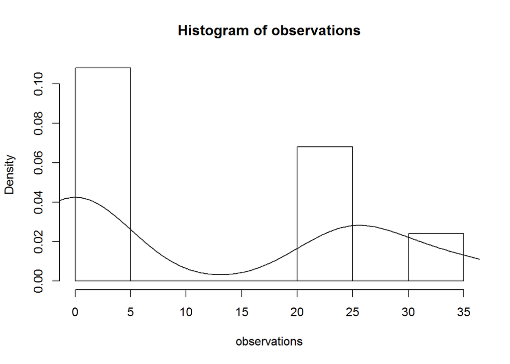

```r
{
  print("How raw data look as histogram")
  hist(observations, prob=TRUE)
  lines(density(observations))
}
```

```
## [1] "How a simulation with calculated standard deviation and mean"
```

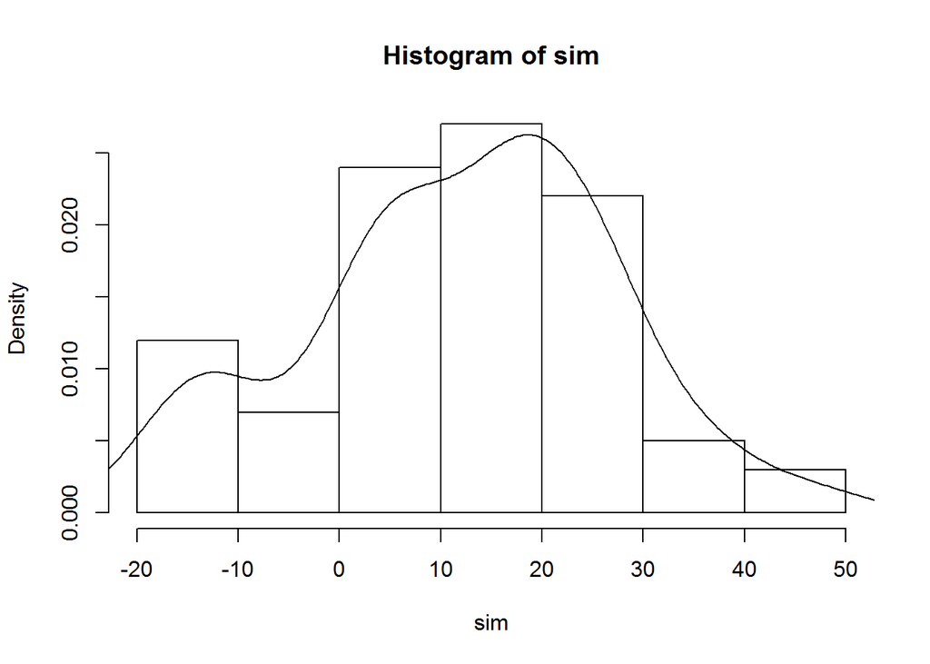

```r
{
  print("How a simulation with calculated standard deviation and mean")
  sim <- rnorm(n=100, mean=mean, sd=sd)
  hist(sim, prob=TRUE)
  lines(density(sim))
}
```

#### b. About how much revenue should the airline expect for a flight of 120 passengers? With what

standard deviation? Note any assumptions you make and if you think they are justified.

## Distributions of random variables 1

**assignment_overview**:

- 3.10 - Heights of 10 year olds
- 3.12 - Speeding on the I-5, Part 1
- 3.20 - Heights of female college students, Part 2
- 3.26 - Speeding on the I-5, Part 2

### 3.10 - Heights of 10 year olds

Heights of 10 year olds, regardless of gender, closely follow a normal distribution with mean 55 inches and standard deviation 6 inches.

#### a. What is the probability that a randomly chosen 10 year old is shorter than 48 inches

```r
{
  mean <- 55
  sd <- 6

  inches <- 48

  cat("The probability for 10 year old shorther than 48 inches: ")
  print(pnorm(q = 48, mean = mean, sd = sd, lower.tail = TRUE))
}
```

```
## The probability for 10 year old shorther than 48 inches: [1] 0.1216725
```

#### b. What is the probability that a randomly chosen 10 year old is between 60 and 65 inches?

```r
{
  mean <- 55
  standard_deviation <- 6

  lower <- pnorm(q = 60, mean = mean, sd = standard_deviation)
  upper <- pnorm(q = 65, mean = mean, sd = standard_deviation)

  cat("The probability for 10 year old between 60 and 65 inches: ")
  print(upper - lower)
}
```

```
## The probability for 10 year old between 60 and 65 inches: [1] 0.154538
```

#### c. If the tallest 10% of the class is considered “very tall”, what is the height cutoff for “very tall”?

```r
{
  mean <- 55
  standard_deviation <- 6

  cutoff <- qnorm(p = 0.9, mean = mean, sd = standard_deviation)

  cat("The cutoff for \"Very Tall\" is: ")
  cat(cutoff)
  print(" Inches!")
}
```

```
## The cutoff for "Very Tall" is: 62.68931[1] " Inches!"
```

#### d. The height requirement for *Batman the Ride* at Six Flags Magic Mountain is 54. What percent of 10 year olds cannot go on this ride?

```r
{
  mean <- 55
  standard_deviation <- 6

  cutoff <- pnorm(q = 54, mean = mean, sd = standard_deviation)

  cat("The cutoff percentage for \"Batman the Ride\" is: ")
  cat(cutoff)
  print("%.")
}
```

```
## The cutoff percentage for "Batman the Ride" is: 0.4338162[1] "%."
```

### 3.12 - Speeding on the I-5, Part 1

The distribution of passenger vehicle speeds traveling on the Interstate 5 Freeway (I-5) in California is nearly normal with a mean of 72.6 miles/hour and a standard deviation of 4.78 miles/hour.

#### a. What percent of passenger vehicles travel slower than 80 miles/hour?

```r
{
  mph_mean <- 72.6
  mph_sd <- 4.78

  under_80 <- pnorm(q = 80, mean = mph_mean, sd = mph_sd)

  cat("Percent of passenger vehicles under 80 mph: ")
  cat(under_80)
  print(".")
}
```

```
## Percent of passenger vehicles under 80 mph: 0.939203[1] "."
```

#### b. What percent of passenger vehicles travel between 60 and 80 miles/hour?

```r
{
  mph_mean <- 72.6
  mph_sd <- 4.78

  under_80 <- pnorm(q = 80, mean = mph_mean, sd = mph_sd)
  under_60 <- pnorm(q = 60, mean = mph_mean, sd = mph_sd)

  cat("Percent of passenger vehicles under 80 mph: ")
  cat(under_80 - under_60)
  print(".")
}
```

```
## Percent of passenger vehicles under 80 mph: 0.9350083[1] "."
```

#### c. How fast do the fastest 5% of passenger vehicles travel?

```r
{
  mph_mean <- 72.6
  mph_sd <- 4.78

  top5 <- qnorm(p = 0.95, mean = mph_mean, sd = mph_sd)

  cat("Speed of fastest 5% of passenger vehicles: ")
  cat(top5)
  print(" mph and above.")
}
```

```
## Speed of fastest 5% of passenger vehicles: 80.4624[1] " mph and above."
```

#### d. The speed limit on this stretch of the I-5 is 70 miles/hour. Approximate what percentage of the passenger vehicles travel above the speed limit on this stretch of the I-5?

```r
{
  mph_mean <- 72.6
  mph_sd <- 4.78

  above70 <- pnorm(q = 70, mean = mph_mean, sd = mph_sd, lower.tail = F)

  cat("Part of passengers drivin over 70 mph: ")
  cat(above70)
  print(".")
}
```

```
## Part of passengers drivin over 70 mph: 0.7067562[1] "."
```

### 3.20 - Heights of female college students, Part 2

#### Exercise 3.18 lists the heights of 25 female college students. Do these data appear to follow a normal distribution? Explain your reasoning using the graphs provided below.

*Figures found in the book on page: 152*

Yes it seems to follow the normal distribution. With more samples however it would be even more likely to follow the normal distribution.

### 3.26 - Speeding on the I-5, Part 2

Exercise 3.12 states that the distribution of speeds of cars traveling on the Interstate 5 Freeway (I-5) in California is nearly normal with a mean of 72.6 miles/hour and a standard deviation of 4.78 miles/hour. The speed limit on this stretch of the I-5 is 70 miles/hour.

#### a. A highway patrol officer is hidden on the side of the freeway. What is the probability that 5 cars pass and none are speeding? Assume that the speeds of the cars are independent of each other.

```r
{
  mph_mean <- 72.6
  mph_sd <- 4.78

  prob_not_speeding <- pnorm(q = 70, mean = mph_mean, sd = mph_sd)

  chance_5_not_speeding <- prob_not_speeding ^ 5

  cat("The chance that 5 car passes without speeding is: ")
  print(chance_5_not_speeding)
}
```

```
## The chance that 5 car passes without speeding is: [1] 0.002168423
```

#### b. On average, how many cars would the highway patrol officer expect to watch until the first car that is speeding? What is the standard deviation of the number of cars he would expect to watch?

```r
{
  mph_mean <- 72.6
  mph_sd <- 4.78

  prob_speeding <- pnorm(q = 70, mean = mph_mean, sd = mph_sd, lower.tail = F)

  # Mean described as 1 / p, where p is probability
  speeding_mean <- 1 / prob_speeding

  cat("The average amount of cars before a speeding car: ")
  print(speeding_mean)

  # Standard Deviation described as sd = sqrt((1 - p) / (p ^ 2))
  speeding_sd = sqrt((1 - prob_speeding) / (prob_speeding ^ 2))

  cat("The Standard Deviation of the number of cars he would expect to watch: ")
  print(speeding_sd)
}
```

```
## The average amount of cars before a speeding car: [1] 1.414915
## The Standard Deviation of the number of cars he would expect to watch: [1] 0.7662046
```

## Distribution of random variables 2

**Assignment_Overview**:

- 3.28 - Chickenpox, Part 1
- 3.40 - Male Children

### 3.28 - Chickenpox, Part 1

The National Vaccine Information Center estimates that 90% of Americans have had chickenpox by the time they reach adulthood

#### a. Suppose we take a random sample of 100 American adults. Is the use of the binomial distribution appropriate for calculating the probability that exactly 97 had chickenpox before they reached adulthood? Explain.

Yes. Actually the binomial distribution is made just for that.

#### b. Calculate the probability that exactly 97 out of 100 randomly sampled American adults had chickenpox during childhood.

```r
{
  chickenpox_prob <- 0.90
  chance <- dbinom(x = 97, size = 100, prob = chickenpox_prob)

  cat("The probability for 97 out of 100 randomly sampled american adults had chickenpox during childhood is: ")
  print(chance)
}
```

```
## The probability for 97 out of 100 randomly sampled american adults had chickenpox during childhood is: [1] 0.005891602
```

#### c. What is the probability that exactly 3 out of a new sample of 100 American adults have not had chickenpox in their childhood?

```r
{
  chickenpox_prob <- 0.90
  chance <- dbinom(x = 3, size = 100, prob = (1 - chickenpox_prob))

  cat("The probability that 3 out of 100 randomly sampled american adults did not have chickenpox during childhood: ")
  print(chance)
}
```

```
## The probability that 3 out of 100 randomly sampled american adults did not have chickenpox during childhood: [1] 0.005891602
```

#### d. What is the probability that at least 1 out of 10 randomly sampled American adults have had chickenpox?

```r
{
  chickenpox_prob <- 0.90
  chance <- pbinom(q = 1, size = 10, prob = chickenpox_prob, lower.tail = F)

  cat("The probability that at least 1 out of 10 randomly sampled american adults did have chickenpox: ")
  print(chance)
}
```

```
## The probability that at least 1 out of 10 randomly sampled american adults did have chickenpox: [1] 1
```

#### e. What is the probability that at most 3 out of 10 randomly sampled American adults have not had chickenpox?

```r
{
  chickenpox_prob <- 0.90
  chance <- pbinom(q = 3, size = 10, prob = (1 - chickenpox_prob), lower.tail = T)

  cat("The probability that at most 3 out of 10 randomly sampled american adults did have chickenpox: ")
  print(chance)
}
```

```
## The probability that at most 3 out of 10 randomly sampled american adults did have chickenpox: [1] 0.9872048
```

### 3.40 - Male Children

While it is often assumed that the probabilities of having a boy or a girl are the same, the actual probability of having a boy is slightly higher at 0.51. Suppose a couple plans to have 3 kids.

#### a. Use the binomial model to calculate the probability that two of them will be boys.

```r
{
  male_prob <- 0.51
  chance <- dbinom(x = 2, size = 3, prob = male_prob)

  cat("The probability that out of 3 children 2 will be boys: ")
  print(chance)
}
```

```
## The probability that out of 3 children 2 will be boys: [1] 0.382347
```

#### b. Write out all possible orderings of 3 children, 2 of whom are boys. Use these scenarios to calculate the same probability from part (a) but using the Addition Rule for disjoint events. Confirm that your answers from parts (a) and (b) match.

Where 1 = boy and 0 = girl

**Write outs:** { {1, 1, 0}, {1, 0, 1}, {0, 1, 1}, }

```r
{
  male_prob <- 0.51

  # P(1, 1, 0)
  p1 <- 0.51 * 0.51 * 0.49
  # P(1, 0, 1)
  p2 <- 0.51 * 0.49 * 0.51
  # P(0, 1, 1)
  p3 <- 0.49 * 0.51 * 0.51

  # P1 OR P2 OR P3
  total <- p1 + p2 + p3

  # Can also just be done like this
  total <- ((0.51 ^ 2) * 0.49) * 3

  cat("The probability that out of 3 children 2 will be boys: ")
  print(total)
}
```

```
## The probability that out of 3 children 2 will be boys: [1] 0.382347
```

#### c. If we wanted to calculate the probability that a couple who plans to have 8 kids will have 3 boys, briefly describe why the approach from part (b) would be more tedious than the approach from part (a).

Because it evolved polynominally and therefore quickly escalate in the amount of possible scenarius.

## Foundations for inference 1

**Assignment_Overview**:

- 4.4 - Heights of adults
- 4.12 - Thanksgiving spending, Part 1
- 4.32 - Speed reading, Part 1

### 4.4 - Heights of adults

Researchers studying anthropometry collected body girth measurements and skeletal diameter measurements, as well as age, weight, height and gender, for 507 physically active individuals. The histogram below shows the sample distribution of heights in centimeters.

*Figure in book on page: 198.*

Correspond table to figure:

| Key | Value |
| --- | --- |
| Min | 147.2 |
| Q1 | 163.8 |
| Median | 170.3 |
| Mean | 171.1 |
| SD | 9.4 |
| Q3 | 177.8 |
| Max | 198.1 |

#### a. What is the point estimate for the average height of active individuals? What about the median?

The point estimate of the average is: 171.1

The point estimate for the median is: 170.3

#### b. What is the point estimate for the standard deviation of the heights of active individuals? What about the IQR?

The point estimate for the standard deviation is: 9.4

for IQR: - Q1: 163.8 - Q3: 177.8

#### c. Is a person who is 1m 80cm (180 cm) tall considered unusually tall? And is a person who is 1m 55cm (155cm) considered unusually short? Explain your reasoning.

```r
{
  mean <- 171.1
  sd <- 9.4

  cat("probability for 180 cm and over: ")
  # Outputs 0.1718682
  print(pnorm(q = 180, mean = mean, sd = sd, lower.tail = FALSE))
}
```

```
## probability for 180 cm and over: [1] 0.1718682
```

That is not considered “Unusually”, If it was less than 5% it would be unusual

```r
{
  mean <- 171.1
  sd <- 9.4

  cat("probability for 155 cm and under: ")
  # Outputs 0.0433778
  print(pnorm(q = 155, mean = mean, sd = sd, lower.tail = TRUE))
}
```

```
## probability for 155 cm and under: [1] 0.0433778
```

The short person would however be considered unusually short as under 5% of the sample would result in such a short person.

#### d. The researchers take another random sample of physically active individuals. Would you expect the mean and the standard deviation of this new sample to be the ones given above? Explain your reasoning

It wouldn’t be exactly the same, but it would look nearly the same.

#### e. The sample means obtained are point estimates for the mean height of all active individuals, if the sample of individuals is equivalent to a simple random sample. What measure do we use to quantify the variability of such an estimate? Compute this quantity using the data from the original sample under the condition that the data are a simple random sample.

To make a random sampling, the use of mean nd standard deviation can be used

```r
{
  size <- 1000;
  mean <- 171.1
  sd <- 9.4

  sample <- rnorm(n = size, mean = mean, sd = sd)

  summary(sample)
}
```

```
##    Min. 1st Qu.  Median    Mean 3rd Qu.    Max.
##   144.4   164.4   171.2   171.2   178.0   206.6
```

### 4.12 - Thanksgiving spending, Part 1

The 2009 holiday retail season, which kicked off on November 27, 2009 (the day after Thanksgiving), had been marked by somewhat lower self-reported consumer spending than was seen during the comparable period in 2008. To get an estimate of consumer spending, 436 randomly sampled American adults were surveyed. Daily consumer spending for the six-day period after Thanksgiving, spanning the Black Friday weekend and Cyber Monday, averaged $84.71. A 95% confidence interval based on this sample is ($80.31, $89.11). Determine whether the following statements are true or false, and explain your reasoning.

*Figure is found in the book on page: 200*

#### a. We are 95% confident that the average spending of these 436 American adults is between $80.31 and $89.11.

False, Since the data is very right skewed the rule for normality is not validated.

#### b. This confidence interval is not valid since the distribution of spending in the sample is right skewed

True

#### c. 95% of such random samples would have a sample mean between $80.31 and $89.11.

False

#### d. We are 95% confident that the average spending of all American adults is between $80.31 and $89.11.

False

#### e. A 90% confidence interval would be narrower than the 95% confidence interval.

True

#### f. In order to decrease the margin of error of a 95% confidence interval to a third of what it is now, we would need to use a sample 3 times larger.

False

#### g. The margin of error for the reported interval is 4.4.

True

### 4.32 - Speed reading, Part 1

A company offering online speed reading courses claims that students who take their courses show a 5 times (500%) increase in the number of words they can read in a minute without losing comprehension. A random sample of 100 students yielded an average increase of 415% with a standard deviation of 220%. Is there evidence that the company’s claim is false?

#### a. Are conditions for inference satisfied?

The sample size is over 30 as a general rule of thumb(slides) This means that it satisfies the central limit theorem

so *yes*.

#### b. Perform a hypothesis test evaluating if the company’s claim is reasonable or if the true average improvement is less than 500%. Make sure to interpret your response in context of the hypothesis test and the data. Use Alpha = 0.025.

- H0: The Online course can increase the words per minute a person can read and comprehend by 500 %
- H1: The Online course can not Increase the words per minute a person can read and comprehend by 500 %

#### c. Calculate a 95% confidence interval for the average increase in the number of words students can read in a minute without losing comprehension.

```r
{
  cl <- qnorm(1 - 0.025)
  pe <- 415
  sd <- 220

  claim <- 500

  size = 100

  SE <- sd / sqrt(size)
  # using a 95% interval
  Z <- 1.96

  ci <- c(pe - cl * SE, pe + cl * SE)

  print(ci)
}
```

```
## [1] 371.8808 458.1192
```

#### d. Do your results from the hypothesis test and the confidence interval agree? Explain.

```r
{
  cl <- qnorm(1 - 0.025)
  pe <- 415
  sd <- 220

  claim <- 500

  size = 100

  SE <- sd / sqrt(size)
  # using a 95% interval
  Z <- 1.96

  ci <- c(pe - cl * SE, pe + cl * SE)

  if(claim > ci[1] && claim < ci[2]){
    print("The Null hypothesis cannot be rejected")
  } else {
    print("The Null hypothesis can be rejected")
  }

}
```

```
## [1] "The Null hypothesis can be rejected"
```

## Foundations for inference 2

**Assignment Overview**:

- 4.38 - Stats final scores
- 4.46 - Unemployment and relationship problems
- 4.48 - True or false

### 4.38 - Stats final scores

Each year about 1500 students take the introductory statistics course at a large university. This year scores on the final exam are distributed with a median of 74 points, a mean of 70 points, and a standard deviation of 10 points. There are no students who scored above 100 (the maximum score attainable on the final) but a few students scored below 20 points.

#### a. Is the distribution of scores on this final exam symmetric, right skewed, or left skewed?

Would appear to be left skewed as the mean is lesser than the median, and it is nearly half a standard deviation less.

#### b. Would you expect most students to have scored above or below 70 points?

Since the median is 74, more than half has certainly scored above 70 points.

#### c. Can we calculate the probability that a randomly chosen student scored above 75 using the normal distribution?

Since the sample is over the size of 30, it could be done according to the slides.

#### d. What is the probability that the average score for a random sample of 40 students is above 75?

```r
{
  # What we need to find is how many standard errors away the result is.

  pe <- 70
  sd <- 10

  size <- 1500

  randomAverage = 75

  se <- sd / sqrt(40)

  # SE's from 75 to 70

  range <- (randomAverage - pe) / se

  # Times 2 because it is onetailed, We are not interested in whats less than
  pnorm(pe, mean = randomAverage, sd = se) * 2
}
```

```
## [1] 0.001565402
```

#### e. How would cutting the sample size in half affect the standard error of the mean?

```r
{
  # What we need to find is how many standard errors away the result is.

  pe <- 70
  sd <- 10

  size <- 1500

  randomAverage = 75

  se <- sd / sqrt(20)

  # SE's from 75 to 70

  range <- (randomAverage - pe) / se

  # Times 2 because it is onetailed, We are not interested in whats less than
  pnorm(pe, mean = randomAverage, sd = se) * 2
}
```

```
## [1] 0.02534732
```

As seen the probability increases. Additionally the Standard error has been increased as a larger sample has a lower standard error.

### 4.46 - Unemployment and relationship problems

A USA Today/Gallup poll conducted between 2010 and 2011 asked a group of unemployed and underemployed Americans if they have had major problems in their relationships with their spouse or another close family member as a result of not having a job (if unemployed) or not having a full-time job (if underemployed). 27% of the 1,145 unemployed respondents and 25% of the 675 underemployed respondents said they had major problems in relationships as a result of their employment status.

#### a. What are the hypotheses for evaluating if the proportions of unemployed and underemployed people who had relationship problems were different?

H0: theres no difference in which unemployed and underemployed have had major problems in their relationship with their spouse or another close family member as a result of not having a job (if unemployed) or not having a full-time job (if underemployed)

H1: There is a difference in which unemployed and underemployed have had major problems in their relationship with their spouse or another close family member as a result of not having a job (if unemployed) or not having a full-time job (if underemployed)

#### b. The p-value for this hypothesis test is approximately 0.35. Explain what this means in context of the hypothesis test and the data.

It means that the Null hypothesis can not be rejected.

and that based on my hypothesis would apply the following:

theres no difference in which unemployed and underemployed have had major problems in their relationship with their spouse or another close family member as a result of not having a job (if unemployed) or not having a full-time job (if underemployed)

### 4.48 - True or false

Determine if the following statements are true or false, and explain your reasoning. If false, state how it could be corrected.

#### a. If a given value (for example, the null hypothesized value of a parameter) is within a 95% confidence interval, it will also be within a 99% confidence interval.

Answer: **True**

#### b. Decreasing the significance level (a) will increase the probability of making a Type 1 error.

Answer: **False**

Correction:

Decreasing the significance level gives a higher confidence interval, which increases the chance of a **type 2 error** not **type 1 error**

#### c. Suppose the null hypothesis is µ = 5 and we fail to reject H 0 . Under this scenario, the true population mean is 5.

Answer: False

Correction:

It is likely to be 5, but could be different.

#### d. If the alternative hypothesis is true, then the probability of making a Type 2 error and the power of a test add up to 1.

Answer: False

Correction:

It should not add up to 1

#### e. With large sample sizes, even small differences between the null value and the true value of the parameter, a difference often called the effect size, will be identified as statistically significant.

Answer: True

#### f. A cutoff of a = 0.05 is the ideal value for all hypothesis tests.

Answer: False

Correction:

Different kind of tests need different kind of assurance.

For rocket science you wan’t to be somewhat more “sure”. for say.

## Inference for Numerical Data 1

**Assignment Overview**:

- 5.1 - Global warming, Part 1
- 5.14 - Child care hours, Part 1
- 5.20 - Fuel efficiency of Prius

### 5.1 - Global warming, Part 1

Is there strong evidence of global warming? Let’s consider a small scale example, comparing how temperatures have changed in the US from 1968 to 2008. The daily high temperature reading on January 1 was collected in 1968 and 2008 for 51 randomly selected locations in the continental US. Then the difference between the two readings (temperature in 2008 - temperature in 1968) was calculated for each of the 51 different locations. The average of these 51 values was 1.1 degrees with a standard deviation of 4.9 degrees. We are interested in determining whether these data provide strong evidence of temperature warming in the continental US.

#### a. Is there a relationship between the observations collected in 1968 and 2008? Or are the observations in the two groups independent? Explain.

There is a relationship, since for the 51 places the same test was conducted twice.

#### b. Write hypotheses for this research in symbols and in words

- H0: There is not a strong evidence of temperature warming in the continental US.
- H1: There is a strong evidence of temperature warming in the continental US.

#### c. Check the conditions required to complete this test.

The data is all paired, no mixing. There appear more than 30 entries.

#### d. Calculate the test statistic and find the p-value.

```r
{
  p_diff <- 1.1
  sd_diff <- 4.9

  size <- 51

  Z <- 1.1 / (sd_diff / sqrt(size))

  # Outputs 0.0544477
  p = 1 - pnorm(Z, mean = 0, sd = 1)

  cat("The P-Value is: ")
  print(p)
}
```

```
## The P-Value is: [1] 0.0544477
```

#### e. What do you conclude? Interpret your conclusion in context.

Since the p value is between 0.05 and 0.1 there is only weak evidence against H0

Therefore H0 can not be rejected

#### f. What type of error might we have made? Explain in context what the error means.

There is a chance of a type 2 error.

The chance for type 2 error could be reduced by increasing the size of observations.

#### g. Based on the results of this hypothesis test, would you expect a confidence interval for the average difference between the temperature measurements from 1968 and 2008 to include 0? Explain your reasoning.

Yes.

The calculation for the confident level would for the sample be the following:

```r
{
  p_diff <- 1.1
  sd_diff <- 4.9

  size <- 51

  se_diff <- sd_diff / sqrt(size)

  # Using 95 % interval
  c(p_diff - 1.96 * se_diff, p_diff + 1.96 * se_diff)
}
```

```
## [1] -0.244829  2.444829
```

### 5.14 - Child care hours, Part 1

The China Health and Nutrition Survey aims to examine the effects of the health, nutrition, and family planning policies and programs implemented by national and local governments. One of the variables collected on the survey is the number of hours parents spend taking care of children in their household under age 6 (feeding, bathing, dressing, holding, or watching them). In 2006, 487 females and 312 males were surveyed for this question. On average, females reported spending 31 hours with a standard deviation of 31 hours, and males reported spending 16 hours with a standard deviation of 21 hours. Calculate a 95% confidence interval for the difference between the average number of hours Chinese males and females spend taking care of their children under age 6. Also comment on whether this interval suggests a significant difference between the two population parameters. You may assume that conditions for inference are satisfied

```r
{
  size_f <- 487
  size_m <- 312

  pi <- 31 - 16

  sd_f <- 31
  sd_m <- 21

  se <- sqrt((sd_f^2 / size_f) + (sd_m^2 / size_m))

  c(pi - 1.96 * se, pi + 1.96 * se)
}
```

```
## [1] 11.39298 18.60702
```

It would appear that women in general use way more time with their children less than age 6

### 5.20 - Fuel efficiency of Prius

#### a. We would like to use these data to evaluate the average gas mileage of all 2012 Prius drivers. Do you think this is reasonable? Why or why not?

Since there is no garantee that the data is even valid or accurate at all it would not a reasonable evaluation. Also only 14 users have submitted data, which increasingly make it hard to validate as the sample size is that low.

#### b. The EPA claims that a 2012 Prius gets 50 MPG (city and highway mileage combined). Do these data provide strong evidence against this estimate for drivers who participate on fueleconomy.gov? Note any assumptions you must make as you proceed with the test.

Assuming the data is in a standard distribution and the data is accurate.

H0: The drivers on fueleconomy.gov is not wrong H1: The drivers on fueleconomy.gov is wrong

Using a 95 % confident level

```r
{
  size <- 14

  pe <- 53.3
  sd <- 5.2

  claim <- 50

  se <- 5.2 / sqrt(14)

  ci <- c(pe - 1.96 * se, pe + 1.96 * se)

  if(ci[1] < claim && ci[2] > claim){
    print("Null Hypothesis can not be rejected")
  } else {
    print("Null hypothesis can be rejected")
  }
}
```

```
## [1] "Null hypothesis can be rejected"
```

#### c. Calculate a 95% confidence interval for the average gas mileage of a 2012 Prius by drivers who participate on fueleconomy.gov.

```r
{
  size <- 14

  pe <- 53.3
  sd <- 5.2

  claim <- 50

  se <- 5.2 / sqrt(14)

  c(pe - 1.96 * se, pe + 1.96 * se)
}
```

```
## [1] 50.57607 56.02393
```

## Inference for Numerical Data 2

**Assignment Overview**:

- 5.30 - Fuel efficiency of manual and automatic cars, Part 1
- 5.40 - Work hours and education, Part 3

### 5.30 - Fuel efficiency of manual and automatic cars, Part 1

Each year the US Environmental Protection Agency (EPA) releases fuel economy data on cars manufactured in that year. Below are summary statistics on fuel efficiency (in miles/gallon) from random samples of cars with manual and automatic transmissions manufactured in 2012. Do these data provide strong evidence of a difference between the average fuel efficiency of cars with manual and automatic transmissions in terms of their average city mileage? Assume that conditions for inference are satisfied.

*Figures in the book on page: 256.*

*Sketched data from book figure*

| Table | Automatic | Manual |
| --- | --- | --- |
| Mean | 22.92 | 27.88 |
| SD | 5.29 | 5.01 |
| n | 26 | 26 |

Also assuming that the 26 in the sample pool for both samples are the same car apart from the gearing.

- H0: Where is no difference in miles per galon a car drives regardless gearing
- H1: Where is a difference in miles per galon a car drives regardless gearing

```r
{
  diff <- 22.92 - 27.88

  sd_a <- 5.29
  sd_m <- 5.01

  size <- 26

  se <- sqrt((sd_a^2 / size) + (sd_m^2 / size))

  t <- diff / se

  if(pt(q = t, df = size) < 0.050) {
    print("The Null hypothesis is rejected")
  } else {
    print("Failed to reject null hypothesis")
  }
}
```

```
## [1] "The Null hypothesis is rejected"
```

### 5.40 - Work hours and education, Part 3

In Exercises 5.8 and 5.10 you worked with data from the General Social Survey in order to compare the average number of hours worked per week by US residents with and without a college degree. However, this analysis didn’t take advantage of the original data which contained more accurate information on educational attainment (less than high school, high school, junior college, Bachelor’s, and graduate school). Using ANOVA, we can consider educational attainment levels for all 1,172 respondents at once instead of re-categorizing them into two groups. Below are the distributions of hours worked by educational attainment and relevant summary statistics that will be helpful in carrying out this analysis.

| educational attainment | Less than HS | HS | Jr Coll | Bachelor’s | Graduate | Total |
| --- | --- | --- | --- | --- | --- | --- |
| Mean | 38.67 | 39.6 | 41.39 | 42.55 | 40.85 | 40.45 |
| SD | 15.81 | 14.97 | 18.1 | 13.62 | 15.51 | 15.17 |
| n | 121 | 546 | 97 | 253 | 155 | 1,172 |

So ANOVA is used to figure out if any of the categories stick out

H0: The mean outcome is the same across all categories. H1: At least one mean is different from the others.

```r
{
  dfg <- 6 - 1
  dft <- 1172
  dfe <- dft - dfg

  total_avg <- 40.45
  total_sd <- 15.17

  ssg <- 121 * (38.67 - 40.45)^2
  ssg <- (546 * (39.6 - 40.45)^2) + ssg
  ssg <- (97 * (41.39 - 40.45)^2) + ssg
  ssg <- (253 * (42.55 - 40.45)^2) + ssg
  ssg <- (155 * (40.85 - 40.45)^2) + ssg

  sse <- (121 - 1) * 15.81^2
  sse <- ((546 - 1) * 14.97^2) + sse
  sse <- ((97 - 1) * 18.1^2) + sse
  sse <- ((253 - 1) * 13.62^2) + sse
  sse <- ((155 - 1) * 15.51^2) + sse

  sst <- ssg + sse

  msg <- ssg / dfg
  mse <- sse / dfe

  # F -> 1.749451
  msg / mse
}
```

```
## [1] 1.749451
```

Using http://www.danielsoper.com/statcalc3/calc.aspx?id=7 to calculate probability:

Probability around 12 %

## Inference for Categorical Data

**Assignment Overview**:

- 6.12 - Legalization of marijuana, Part 1
- 6.14 - The Civil War

### 6.12 - Legalization of marijuana, Part 1

The 2010 General Social Survey asked 1,259 US residents: “Do you think the use of marijuana should be made legal, or not?” 48% of the respondents said it should be made legal

#### a. Is 48% a sample statistic or a population parameter? Explain.

It is a sample statistics. The population parameter would be the result of all US residents.

#### b. Construct a 95% confidence interval for the proportion of US residents who think marijuana should be made legal, and interpret it in the context of the data.

```r
{
  p <- 0.48

  size <- 1259

  ME <- 1.96 * sqrt(p * (1 - p) / size)

  # 0.4524028   0.5075972
  c(p - ME, p + ME)
}
```

```
## [1] 0.4524028 0.5075972
```

#### c. A critic points out that this 95% confidence interval is only accurate if the statistic follows a normal distribution, or if the normal model is a good approximation. Is this true for these data? Explain.

The data has 10 failure and successes

it also has over 30 entries

So it would be a normal distribution

#### d. A news piece on this survey’s findings states, “Majority of Americans think marijuana should be legalized.” Based on your confidence interval, is this news piece’s statement justified?

Since the interval covers a value over 50 % it can not be rejected that a majority of americans think marijuana should be legalized

### 6.14 - The Civil War

A national survey conducted in 2011 among a simple random sample of 1,507 adults shows that 56% of Americans think the Civil War is still relevant to American politics and political life.

#### a. Conduct a hypothesis test to determine if these data provide strong evidence that the majority of the Americans think the Civil War is still relevant.

- H0: A majority of americans think the civil war is still relevant
- H1: Less than a majority of americans think the civil war is still relevant

#### b. Interpret the p-value in this context.

```r
{
  p <- 0.56

  size <- 1507

  SE <- sqrt(p * (1 - p) / size)

  pnorm(0.5, mean = p, sd = SE)
}
```

```
## [1] 1.350628e-06
```

#### c. Calculate a 90% confidence interval for the proportion of Americans who think the Civil War is still relevant. Interpret the interval in this context, and comment on whether or not the confidence interval agrees with the conclusion of the hypothesis test

```r
{
  p <- 0.56

  size <- 1507

  ME <- 1.645 * sqrt(p * (1 - p) / size)

  # 0.5389656    0.5810344
  c(p - ME, p + ME)
}
```

```
## [1] 0.5389656 0.5810344
```

Using the 90 % confident level, it is clear that the null hypothesis can not be rejected.

It is Very very very very unlikely that the Null Hypothesis would be rejected as the p value was exceptional small.